# Спецификация к типовому расчету

# "Процедуры, функции, модули"

# по дисциплине «Программирование»

# 1 семестр

# (Вариант 22)

## Абстракция А0

### 1. Постановка задачи.

#### Задание:

Написать программу обработки двух матриц в соответствии с условием.

#### Условие:

Дана матрица $A$ из $N$ строк и $N$ столбцов.

Кроме матрицы $A$ дана матрица $B$ такого же размера.

Если каждый элемент матрицы $A$ больше соответствующего элемента матрицы $B$,

присвоить элементам $C_1, C_2, ..., C_N$ значения по правилу:

$\displaystyle{C_i = \sum_{k=1}^{N} (A_{ik} + B_{ik}) \ (*)}$

### 2. Уточненная постановка задачи.

Дана две квадратные матрицы $A$ и $B$, состоящие из N строк и N столбцов.

Сравнить соответствующие элементы матриц $A$ и $B$.

Если $A_{ij} > B_{ij}, \forall i, j: 0 < i < N+1, 0 < j < N+1$, то

сформирмировать одномерный массив $C_1, C_2, ..., C_N$ по правилу $(*)$.

### 3. Пример с иллюстрацией.

```python
from IPython.display import Image
import numpy
import pylab
%matplotlib inline
pylab.style.use('seaborn-whitegrid')
```

```python
def write_datatxt(file_name, N, A, B):
    with open(file_name, 'w') as f:
        for M in [A, B]:
            for i in range(N):
                f.write("{}\n".format(M[i]))
```

```python
N1 = 5
A1 = numpy.random.randint(0, 100, size=(N1,N1))
B1 = numpy.random.randint(-100, 0, size=(N1,N1))
write_datatxt('AB_SC_1.txt', N1, A1, B1)
print('\n', N1, '\n\n', A1, '\n\n', B1)
```

```
 5

 [[38 74 64 76 99]
 [53 98 15 33 45]
 [91 49 97 84 90]
 [22 48 83  0 63]
 [99 52 33 99 48]]

 [[-76 -98 -99 -98 -82]
 [-16 -22 -65 -83 -75]
 [-25 -76 -66  -8  -2]
 [-70 -45 -74 -70 -43]
 [-37 -84 -64  -3 -94]]
```

```python
N2 = 5
A2 = numpy.random.randint(1, 3, size=(N2,N2))
B2 = numpy.random.randint(-2, 0, size=(N2,N2))
write_datatxt('AB_SC_2.txt', N2, A2, B2)
print('\n', N2, '\n\n', A2, '\n\n', B2)
```

```
 5

 [[2 1 1 2 1]
 [2 2 2 1 1]
 [1 1 1 1 1]
 [1 1 1 1 2]
 [1 2 1 1 2]]

 [[-1 -1 -1 -1 -1]
 [-1 -1 -1 -2 -1]
 [-2 -1 -2 -2 -1]
 [-1 -1 -2 -2 -2]
 [-1 -2 -1 -2 -2]]
```

```python
N3 = 5
A3 = numpy.random.randint(0, 2, size=(N3,N3))
B3 = numpy.random.randint(0, 2, size=(N3,N3))
write_datatxt('AB_SC_3.txt', N3, A3, B3)
print('\n', N3, '\n\n', A3, '\n\n', B3)
```

```
 5

 [[1 1 0 0 0]
 [0 0 0 1 1]
 [0 0 0 0 0]
 [0 1 1 0 0]
 [1 1 0 0 1]]

 [[0 0 1 1 0]
 [1 1 1 0 0]
 [0 1 0 1 0]
 [1 1 0 0 0]
 [0 0 1 1 1]]
```

```python
N4 = 5
A4 = numpy.random.randint(1, 10, size=(N4,N4))
B4 = numpy.random.randint(-10, 0, size=(N4,N4))
write_datatxt('AB_SC_4.txt', N4, A4, B4)
print('\n', N4, '\n\n', A4, '\n\n', B4)
```

```
 5

 [[7 6 9 7 4]
 [6 9 2 1 2]
 [3 1 2 7 5]
 [3 4 8 3 1]
 [3 6 2 1 2]]

 [[ -9  -8  -2  -9 -10]
 [ -9  -6  -3  -7  -8]
 [-10 -10  -1  -7  -9]
 [ -6  -7  -3  -9  -8]
 [ -2  -9  -8  -7  -5]]
```

```python
N5 = 5
A5 = numpy.random.randint(0, 10, size=(N5,N5))
B5 = numpy.random.randint(0, 9, size=(N5,N5))
write_datatxt('AB_SC_5.txt', N5, A5, B5)
print('\n', N5, '\n\n', A5, '\n\n', B5)
```

```
 5

 [[5 1 8 2 8]
 [4 3 6 0 8]
 [0 0 3 8 5]
 [5 3 1 2 3]
 [1 3 9 8 0]]

 [[5 0 7 6 7]
 [7 3 6 2 5]
 [1 6 6 1 4]
 [2 4 8 4 4]
 [4 5 3 0 0]]
```

```python
print(20*' ' + 'Лаб.12 Типовой Расчет \n' + 90*'=')

fin = str(input('Текстовый файл с элементами исходных матриц: '))
fout = str(input('Текстовый файл с элементами исходных матриц и результатами: '))

#fin = 'AB_SC_1.txt', 'AB_SC_2.txt', AB_SC_3.txt', AB_SC_4.txt', AB_SC_5.txt'
#fout = 'ABC_SC_1.txt', 'ABC_SC_2.txt', 'ABC_SC_3.txt', 'ABC_SC_4.txt', 'ABC_SC_5.txt'

with open(fin, 'r') as f:
    Y = f.readlines()
Y = [x[1:-2].split() for x in Y]
Y = [[int(x) for x in Y[i]] for i in range(len(Y))]

A, B = Y[:int(len(Y)/2)], Y[int(len(Y)/2):]

print('Исходная матрица A: \n' + 90*'=' + '\n')
for i in range(len(A)):
    print("{}\n".format(A[i]))

print('Исходная матрица B: \n' + 90*'=' + '\n')
for i in range(len(B)):
    print("{}\n".format(B[i]))

C = [A[i][j] > B[i][j] for i in range(len(A)) for j in range(len(A))]
if sum(C) == len(C):
    C = [sum([A[i][j] + B[i][j] for j in range(len(A))]) for i in range(len(A))]
    print('Сформированный массив C: \n' + 90*'=' + '\n' + str(C))
else:
    print('Не все элементы матрицы A больше соответствующих элементов матрицы B')


with open(fout, 'w') as f:
    for i in range(len(A)):
        f.write("{}\n".format(A[i]))
    for i in range(len(B)):
        f.write("{}\n".format(B[i]))
    f.write("{}\n".format(C))
```

```
                    Лаб.12 Типовой Расчет
==========================================================================================
Текстовый файл с элементами исходных матриц: AB_SC_1.txt
Текстовый файл с элементами исходных матриц и результатами: ABC_SC_1.txt
Исходная матрица A:
==========================================================================================

[38, 74, 64, 76, 99]

[53, 98, 15, 33, 45]

[91, 49, 97, 84, 90]

[22, 48, 83, 0, 63]

[99, 52, 33, 99, 48]

Исходная матрица B:
==========================================================================================

[-76, -98, -99, -98, -82]

[-16, -22, -65, -83, -75]

[-25, -76, -66, -8, -2]

[-70, -45, -74, -70, -43]

[-37, -84, -64, -3, -94]

Сформированный массив C:
==========================================================================================
[-102, -17, 234, -86, 49]
```

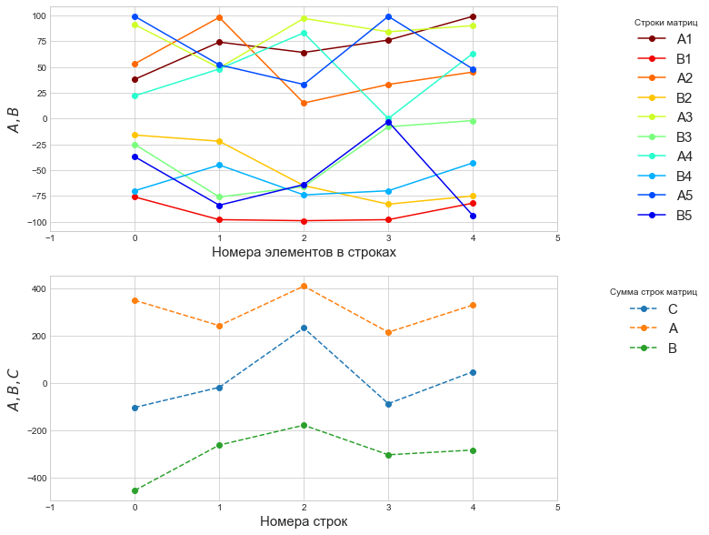

```python
f = pylab.figure(figsize=(10,10))
ax1 = f.add_subplot(2, 1, 1)
ax2 = f.add_subplot(2, 1, 2)
bwr = pylab.cm.get_cmap('jet_r')

for i in range(len(B)):
    ax1.plot(range(len(A[i])), A[i], '-o',
               c=bwr(2*i/10), label='A' + str(i+1))
    ax1.plot(range(len(B[i])), B[i], '-o',
               c=bwr((2*i+1)/10), label='B' + str(i+1))
ax1.legend(title='Строки матриц', fontsize=15,
           shadow=True, bbox_to_anchor=(1.3,1.0))
ax1.set_xticks(range(-1, len(C)+1), range(len(C)+2))
ax1.set_xlabel('Номера элементов в строках', fontsize=15)
ax1.set_ylabel(r'$A, B$', fontsize=15)

ax2.plot(range(len(C)), C, '-o', label='C', ls='--')
ax2.plot(range(len(C)), [sum(A[i]) for i in range(len(C))],
         '-o', label='A', ls='--')
ax2.plot(range(len(C)), [sum(B[i]) for i in range(len(C))],
         '-o', label='B', ls='--')
ax2.legend(title='Сумма строк матриц', fontsize=15,
           shadow=True, bbox_to_anchor=(1.3,1.0))
ax2.set_xticks(range(-1, len(C)+1), range(len(C)+2))
ax2.set_xlabel('Номера строк', fontsize=15)
ax2.set_ylabel(r'$A,B,C$', fontsize=15);
```

### 4. Таблица данных

| Класс | Имя | Описание (смысл, диапазон, точность) | Тип | Структура | Формат в/в |
| --- | --- | --- | --- | --- | --- |
| входные данные | fin | название текстового файла с элементами массива B | символ | строка | "+XX.txt" |
| входные данные | fout | название текстового файла с элементами массива B | символ | строка | "+XX.txt" |
| входные данные | tfin | название текстового файла с элементами массива B | символ | текстовый файл | +XX.txt |
| входные данные | tfout | название текстового файла с элементами массива B | символ | текстовый файл | +XX.txt |
| входные данные | X | вводимый из текстового файла массив, содержащий исходные матрицы | цел | двумерный массив | +XX (:5) |
| входные данные | A, B | исходные матрицы | цел | двумерные массивы | +XX (:5) |
| выходные данные | C | выводимый в текстовый файл сформированный массив | цел | одномерные массивы | +XX (:5) |
| промежуточные данные | i | индекс текущей строки, 1≤i≤50 | цел | простая переменная | --- |
| промежуточные данные | j | индекс текущего столбца, 1≤j≤50 | цел | простая переменная | --- |

### 5. Входная форма

- обр 1.1 Текстовый файл с элементами исходных матриц: $<fin>$
- обр 1.2 Текстовый файл с элементами исходных матриц и результатами: $<fout>$
- обр 2.1 Исходная матрица A:
- обр 2.2 $ < A[11] > < A[12] > … < A[1n] > \\ ... \\ < A[n1] > < A[n2] > … < A[nn] >$
- обр 3.1 Исходная матрица B:
- обр 3.2 $ < B[11] > < B[12] > … < B[1n] > \\ ... \\ < B[n1] > < B[n2] > … < B[nn] >$

### 6. Выходная форма

- обр 4 Лаб. 12 Типовой расчет
- обр 5.1 Текстовый файл с элементами исходных матриц: $<fin>$
- обр 5.2 Текстовый файл с элементами исходных матриц и результатами: $<fout>$
- обр 6.1 Исходная матрица A:
- обр 6.2 $ < A[11] > < A[12] > … < A[1n] > \\ ... \\ < A[n1] > < A[n2] > … < A[nn] >$
- обр 7.1 Исходная матрица B:
- обр 7.2 $ < B[11] > < B[12] > … < B[1n] > \\ ... \\ < B[n1] > < B[n2] > … < B[nn] >$
- обр 8 Некорректное число строк или столбцов
- обр 9.1 Сформированный массив C:
- обр 9.2 $ < C[1] > < C[2] > … < C[n] > $

### 7. Аномалии

| N | Описание | Условие возникновения | Реакция |
| --- | --- | --- | --- |
| 1 | Не входных данных | $X[i,j] = 0 \ \forall i,j$ | Обр 8 |
| 2 | Число строк не равно удвоенному числу столбцов | $i \neq 2j$ | Обр 8 |

### 8. Функциональные тесты

| Исходные данные | - | - | - | Результаты | - | Тест |  |  |  |  |  |  |
| --- | --- | --- | --- | --- | --- | --- | --- | --- | --- | --- | --- | --- |
| fin | fout | A | B | C | Сообщение | № |  |  |  |  |  |  |
| AB_SC_1.txt | ABC_SC_1.txt | `[[38, 74, 64, 76, 99] [53, 98, 15, 33, 45] [91, 49, 97, 84, 90] [22, 48, 83, 0, 63]] [99, 52, 33, 99, 48]]` | `[-76, -98, -99, -98, -82] [-16, -22, -65, -83, -75] [-25, -76, -66, -8, -2] [-70, -45, -74, -70, -43] [-37, -84, -64, -3, -94]` | `[-102, -17, 234, -86, 49]` | - | 1 |  |  |  |  |  |  |
| - | - | - | - | - | - | - |  |  |  |  |  |  |
| AB_SC_2.txt | ABC_SC_2.txt | `[2, 1, 1, 2, 1] [2, 2, 2, 1, 1] [1, 1, 1, 1, 1] [1, 1, 1, 1, 2] [1, 2, 1, 1, 2]` | `[-1, -1, -1, -1, -1] [-1, -1, -1, -2, -1] [-2, -1, -2, -2, -1] [-1, -1, -2, -2, -2] [-1, -2, -1, -2, -2]` | `[2, 2, -3, -2, -1]` | - | 2 |  |  |  |  |  |  |
| - | - | - | - | - | - | - |  |  |  |  |  |  |
| AB_SC_3.txt | ABC_SC_3.txt | `[1, 1, 0, 0, 0] [0, 0, 0, 1, 1] [0, 0, 0, 0, 0] [0, 1, 1, 0, 0] [1, 1, 0, 0, 1]` | `[0, 0, 1, 1, 0] [1, 1, 1, 0, 0] [0, 1, 0, 1, 0] [1, 1, 0, 0, 0] [0, 0, 1, 1, 1]` | - | `Не все элементы матрицы A больше соответствующих элементов матрицы B` | 3 |  |  |  |  |  |  |
| - | - | - | - | - | - | - |  |  |  |  |  |  |
| AB_SC_4.txt | ABC_SC_4.txt | `[7, 6, 9, 7, 4] [6, 9, 2, 1, 2] [3, 1, 2, 7, 5] [3, 4, 8, 3, 1] [3, 6, 2, 1, 2]` | `[-9, -8, -2, -9, -10] [-9, -6, -3, -7, -8] [-10, -10, -1, -7, -9] [-6, -7, -3, -9, -8] [-2, -9, -8, -7, -5]` | `[-5, -13, -19, -14, -17]` | - | 4 |  |  |  |  |  |  |
| - | - | - | - | - | - | - | - | - | - | - | - | - |
| AB_SC_5.txt | ABC_SC_5.txt | `[5, 1, 8, 2, 8] [4, 3, 6, 0, 8] [0, 0, 3, 8, 5] [5, 3, 1, 2, 3] [1, 3, 9, 8, 0]` | `[5, 0, 7, 6, 7] [7, 3, 6, 2, 5] [1, 6, 6, 1, 4] [2, 4, 8, 4, 4] [4, 5, 3, 0, 0]` | - | `Не все элементы матрицы A больше соответствующих элементов матрицы B` | 5 |  |  |  |  |  |  |
| - | - | - | - | - | - | - |  |  |  |  |  |  |

| № теста | Входные данные | - | - | - | Ожидаемый результат | - | Смысл теста |
| --- | --- | --- | --- | --- | --- | --- | --- |
| - | - | - | - | - | - | - | - |
| 1 | fin = `AB_SC_1.txt` | fout = `ABC_SC_1.txt` | A = `[[38, 74, 64, 76, 99] [53, 98, 15, 33, 45] [91, 49, 97, 84, 90] [22, 48, 83, 0, 63]] [99, 52, 33, 99, 48]]` | B = `[-76, -98, -99, -98, -82] [-16, -22, -65, -83, -75] [-25, -76, -66, -8, -2] [-70, -45, -74, -70, -43] [-37, -84, -64, -3, -94]` | C = `[-102, -17, 234, -86, 49]` | - | Подтвердить правильность расчетов в случае широкого спектра положительных и отрицательных чисел |
| - | - | - | - | - | - | - | - |
| 2 | fin = `AB_SC_2.txt` | fout = `ABC_SC_2.txt` | A = `[2, 1, 1, 2, 1] [2, 2, 2, 1, 1] [1, 1, 1, 1, 1] [1, 1, 1, 1, 2] [1, 2, 1, 1, 2]` | B = `[-1, -1, -1, -1, -1] [-1, -1, -1, -2, -1] [-2, -1, -2, -2, -1] [-1, -1, -2, -2, -2] [-1, -2, -1, -2, -2]` | C = `[2, 2, -3, -2, -1]` | - | Протестировать простейший случай |
| - | - | - | - | - | - | - | - |
| 3 | fin = `AB_SC_3.txt` | fout = `ABC_SC_3.txt` | A = `[1, 1, 0, 0, 0] [0, 0, 0, 1, 1] [0, 0, 0, 0, 0] [0, 1, 1, 0, 0] [1, 1, 0, 0, 1]` | B = `[0, 0, 1, 1, 0] [1, 1, 1, 0, 0] [0, 1, 0, 1, 0] [1, 1, 0, 0, 0] [0, 0, 1, 1, 1]` | - | `Не все элементы матрицы A больше соответствующих элементов матрицы B` | Протестировать простейший случай с бинарными значениями элементов |
| - | - | - | - | - | - | - | - |
| 4 | fin = `AB_SC_4.txt` | fout = `ABC_SC_4.txt` | A = `[7, 6, 9, 7, 4] [6, 9, 2, 1, 2] [3, 1, 2, 7, 5] [3, 4, 8, 3, 1] [3, 6, 2, 1, 2]` | B = `[-9, -8, -2, -9, -10] [-9, -6, -3, -7, -8] [-10, -10, -1, -7, -9] [-6, -7, -3, -9, -8] [-2, -9, -8, -7, -5]` | C = `[-5, -13, -19, -14, -17]` | - | Протестировать массив в узком диапазоне положительных и отрицательных чисел |
| - | - | - | - | - | - | - | - |
| 5 | fin = `AB_SC_5.txt` | fout = `ABC_SC_5.txt` | A = `[5, 1, 8, 2, 8] [4, 3, 6, 0, 8] [0, 0, 3, 8, 5] [5, 3, 1, 2, 3] [1, 3, 9, 8, 0]` | B = `[5, 0, 7, 6, 7] [7, 3, 6, 2, 5] [1, 6, 6, 1, 4] [2, 4, 8, 4, 4] [4, 5, 3, 0, 0]` | - | `Не все элементы матрицы A больше соответствующих элементов матрицы B` | Подтвердить правильность расчетов в узком диапазоне положительных чисел |

| - | Результаты | № теста |
| --- | --- | --- |
| - | - | - |
| C | Максимальная вычислительная нагрузка = 25 (сравнения) + 5 (суммирование) | 1 |
| - | Соответствует ожидаемым числовым значениям | - |
| C | Максимальная вычислительная нагрузка = 25 (сравнения) + 5 (суммирование) | 2 |
| - | Соответствует ожидаемым числовым значениям | - |
| C | - | 3 |
| - | Задача не решалась, массивы не соответствуют условиям | - |
| C | Максимальная вычислительная нагрузка = 25 (сравнения) + 5 (суммирование) | 4 |
| - | Соответствует ожидаемым числовым значениям | - |
| C | - | 5 |
| - | Задача не решалась, массивы не соответствуют условиям | - |
| - | - | - |
| Сообщение | - | 1 |
| Сообщение | - | 2 |
| Сообщение | Не все элементы матрицы A больше соответствующих элементов матрицы B | 3 |
| Сообщение | - | 4 |
| Сообщение | Не все элементы матрицы A больше соответствующих элементов матрицы B | 5 |

### 9. Метод

Отделим ввод-вывод от обработки данных и разделим задачу на три подзадачи:

1. *Подзадача А 0.1.*

   Запросить названия текстовых файлов ввода-вывода, считать из текстового файла ввода исходные данные (обр.1-3), затем вывести их на экран (обр.4-7) для визуального подтверждения.

   Вывести сообщение о наличии некорректных данных, если задача не решена (обр.8).
2. *Подзадача А 0.2.* Решение поставленной задачи:
   - 2.1. На основе введенных исходных данных ($A, B$) определить, каждый ли элемент матрицы $A$ больше соответствующего элемента матрицы $B$.
   - 2.2. Если условие 2.1 выполнено, то сформировать новый массив $C$ по правилу $(*)$.
3. *Подзадача А 0.3.* Ввести полученные результаты ($C$) на экран (обр.9.1, 9.2) и записать в файл вывода исходные матрицы и полученный результат.

Ввод-вывод тривиален и представляет собой чисто техническую задачу.

Для осуществления процесса ввода-вывода и обработки матриц потребуются промежуточные переменные:

- `X` - вводимый из текстового файла двумерный массив, содержащий исходны матрицы,
- `n` - размерность исходных матриц,
- `i` – индекс строки текущего элемента матрицы,
- `j` - индекс столбца текущего элемента матрицы.

Их следует добавить в таблицу данных.

Алгоритм необходим только для обработка входных данных и расчета результата.

### 10. Алгоритм

[Sample diagrams](http://blockdiag.com/en/blockdiag/examples.html#sample-diagrams)

```python
%%file block_diagram

blockdiag {
    orientation = portrait;
    class start_end [shape = ellipse, fontsize = 15, color = lightskyblue];
    class input_out [shape = flowchart.input, fontsize = 15, width = 600, color = lightgray];
    class main_box [shape = box, width = 450, height = 150, fontsize = 18];

    Начало ->
    "Вывод заголовка по обр.4 на экран" -> "Ввод имен файлов по обр.1.1,1.2" ->
    "Вывод имен файлов по обр.5.1,5.2 на экран" ->
    "Процедура 1. \nСохранение исходных данных \nв виде матрицы X" ->
    "Процедура 2. \nВывод на экран и в файл \nматриц A,B" ->
    "Процедура 3. \nСравнение \nэлементов матриц A,B \nФормирование \nмассива C" ->
    "Процедура 4. \nВывод на экран и в файл \nмассива C" ->
    Конец;

    Начало, Конец [class = "start_end"];
    "Вывод заголовка по обр.4 на экран", "Ввод имен файлов по обр.1.1,1.2" [class = "input_out"];
    "Вывод имен файлов по обр.5.1,5.2 на экран" [class = "input_out"];
    "Процедура 1. \nСохранение исходных данных \nв виде матрицы X" [class = "main_box"];
    "Процедура 2. \nВывод на экран и в файл \nматриц A,B" [class = "main_box"];
    "Процедура 3. \nСравнение \nэлементов матриц A,B \nФормирование \nмассива C" [class = "main_box"];
    "Процедура 4. \nВывод на экран и в файл \nмассива C" [class = "main_box"];

    "Вывод имен файлов по обр.5.1,5.2 на экран" ->
    "Процедура 1. \nСохранение исходных данных \nв виде матрицы X" [label = 'Вх. A,B', fontsize = 18, textcolor = blue];
    "Процедура 4. \nВывод на экран и в файл \nмассива C" ->
    Конец [label = 'Вых. C', fontsize = 18, textcolor = red];
}
```

```
Overwriting block_diagram
```

```python
!blockdiag block_diagram
```

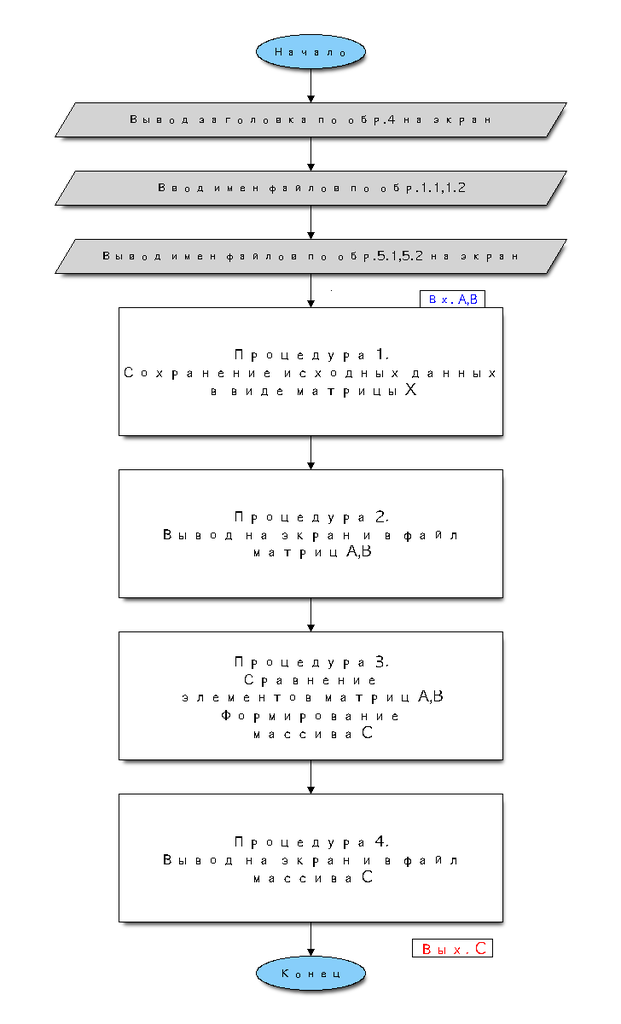

```python
Image("block_diagram.png")
```

### 11. Программа на *Delphi*.

**Диалоговый вариант {ввод названий файлов и данных из текстового файла, вывод на экран и в текстовый файл}**

Синтаксис:

[Pascal Tutorial](https://www.tutorialspoint.com/pascal/index.htm)

```python
program Lab12; // сохранить как lab12.dpr (DPR – Delphi PRoject)
{$APPTYPE CONSOLE}
Uses Windows; //
    type
        M1 = array [1..20,1..10] of integer;
        M2 = array [1..10,1..10] of integer;
        A1 = array [1..10] of integer;

    var
        fin, fout: string;
        tfin, tfout: TextFile;
        i, j, n, t: integer;
        X: M1;
        A, B: M2;
        C: A1;

    procedure read_in(var X: M1; var i, j, n: integer);
    begin
        i := 1;
        while not eof(tfin) do
        begin
            j := 1;
            while not eof(tfin) do
            begin
                read(tfin, X[i,j]);
                j := j + 1;
            end;
            i := i + 1;
            readln(tfin);
        end;
        n := round((i - 1) / 2);
    end;

    procedure write_in(n: integer; X: M1; var A, B: M2; var i, j: integer);
    begin
        writeln('Исходная матрица A');
        i := 1;
        while i < 2 * n + 1 do
        begin
            if i = n + 1 then
                writeln('Исходная матрица B');
            if i < n + 1 then
            begin
                j := 1;
                while j < n + 1 do
                begin
                    A[i,j] := X[i,j];
                    write(A[i,j]:5);
                    write(tfout, A[i,j]:5);
                    j := j + 1;
                end;
            end
            else
            begin
                j := 1;
                while j < n + 1 do
                begin
                    B[i-n,j] := X[i,j];
                    write(B[i-n,j]:5);
                    write(tfout, B[i-n,j]:5);
                    j := j + 1;
                end;
            end;
            writeln; writeln(tfout);
            i := i + 1;
        end;
    end;

    procedure write_out(n: integer; C: A1; var i: integer);
    begin
        writeln('Сформированный массив C');
        i := 1;
        while i < n + 1 do
        begin
            write(C[i]:5);
            write(tfout, C[i]:5);
            i := i + 1;
        end;
        writeln; writeln(tfout);
    end;

    begin
        setConsoleCP(1251); //
        setConsoleOutputCP(1251); //

        {A0.1 - ввод-вывод входных данных}
        writeln('Лаб.12 Типовой Расчет' :40); {вывод заголовка c переходом на следующую строку по обр.4}

        {ввод-вывод строковой переменной - имени файла с входными данными по обр.1.1, 5.1}
        writeln('Текстовый файл с элементами исходных матриц: ');
        readln(fin); writeln(fin);

        {ввод-вывод строковой переменной - имени файла с выходными данными по обр.1.2, 5.2}
        writeln('Текстовый файл с элементами исходных матриц и результатами: ');
        readln(fout); writeln(fout);

        AssignFile(tfin, fin); reset(tfin); {открыть файл для чтения}
        AssignFile(tfout, fout); rewrite(tfout); {открыть файл для записи}

        read_in(X, i, j, n);
        CloseFile(tfin); {закрыть файл для чтения}

        if (i - 1 <> 2 * (j - 1)) then
        begin
            writeln('Некорректное число строк или столбцов');
            exit;
        end;
        write_in(n, X, A, B, i, j);

        {A0.2 - формирование нового массива}
        {заглушка для теста 1}
        C: A1 = (-102, -17, 234, -86, 49);
        {заглушка для теста 2}
        // C: A1 = (2, 2, -3, -2, -1);
        {заглушка для теста 3}
        // writeln('Не все элементы матрицы A больше соответствующих элементов матрицы B');
        {заглушка для теста 4}
        // C: A1 = (-5, -13, -19, -14, -17);
        {заглушка для теста 5}
        // writeln('Не все элементы матрицы A больше соответствующих элементов матрицы B');

        for i := 1 to 40 do
            write('='); {отделим визуально чертой и строкой введенные и выводимые значения}
        writeln;

        {A0.3 - вывод выходных данных}
        write_out(n, C, i);

        CloseFile(tfout); {закрыть файл для записи}

    end.
```

## Раскрытие абстракции А0.2

*Поскольку условие всей задачи совпадает (за исключением необходимости ввода-вывода) с условием выделенной подзадачи,*

*вместо полной спецификации с пунктами 1-11 выполнено просто дополнение к пунктам 9-11.*

### 9. Метод

Пусть

- $i$ – номер текущей строки,
- $j$ – номер текущего столбца,
- $n$ - количество строк и столбцов исходных матриц,
- $X[i,j]$- элемент матрицы $X[2n \times n]$ для чтения исходных данных,
- $A[i,j], B[i,j]$ – соответствующие элементы исходных матриц $A[n \times n], B[n \times n]$,
- $C[i]$ - элемент сформированного массива $C[n] \times 1$ .

*Процедура 1. (Абстракции А0.1)*

Исходные данные сохраняются в виде матрицы $X[2n \times n]$ с помощью циклов по строкам и столбцам.

Или выдается сообщение о некорректных данных.

*Процедура 2. (Абстракции А0.1)*

Формируются матрицы $A[n \times n], B[n \times n]$ и выводятся на экран и в файл с выходными данными.

*Процедура 3. (Абстракции А0.2)*

Сравниваются соответствующие элементы матриц $A[n \times n], B[n \times n]$.

Формируется новый массив $C[n \times 1]$ по правилу $(*)$.

*Процедура 4. (Абстракции А0.3)*

Сформированный массив $C[n \times 1]$ выводится на экран и записывается в файл с выходными данными.

### 10. Алгоритм

[Sample diagrams](http://blockdiag.com/en/blockdiag/examples.html#sample-diagrams)

#### Процедура 3

```python
%%file block_diagram2

blockdiag {
    orientation = portrait;

    class yes [thick, label = "Да", color = blue, textcolor = blue];
    class no [thick, label = "Нет", color = red, textcolor = red];
    class start_end [shape = ellipse, fontsize = 18, color = lightskyblue];
    class input_out [shape = flowchart.input, fontsize = 18,
                     width = 400, color = lightgray];
    class loop_in [shape = flowchart.loopin, fontsize = 18,
                   width = 300, color = lightsteelblue];
    class loop_out [shape = flowchart.loopout, fontsize = 18,
                    width = 300, color = lightsteelblue];
    class condition [shape = flowchart.condition, fontsize = 18,
                     width = 400, height = 100, color = lightsteelblue];
    class command_box [shape = roundedbox, fontsize = 18, width = 300];

    Начало -> "i := 1" -> "while i < n + 1" ->
    "j := 1; C[i] := 0" -> "while j < n + 1" ->
    "A[i,j] > B[i,j]" ->  "C[i] := C[i] + A[i,j] + B[i,j]" ->
    "j := j + 1" -> "i := i + 1"->
    "j = n" -> "i = n" -> Конец;

    "A[i,j] > B[i,j]" ->  Сообщение -> Конец;

    Начало, Конец [class = "start_end"];
    "while i < n + 1", "while j < n + 1" [class = "loop_in"];
    "i = n", "j = n" [class = "loop_out"];
    "A[i,j] > B[i,j]" [class = "condition"];
    "i := 1", "j := 1; C[i] := 0" [class = "command_box"];
    "j := j + 1", "i := i + 1" [class = "command_box"];
    "C[i] := C[i] + A[i,j] + B[i,j]", Сообщение [class = "command_box"];

    "A[i,j] > B[i,j]" -> "C[i] := C[i] + A[i,j] + B[i,j]" [class = 'yes'];
    "A[i,j] > B[i,j]" ->  Сообщение [class = 'no'];
}
```

```
Overwriting block_diagram2
```

```python
!blockdiag block_diagram2
```

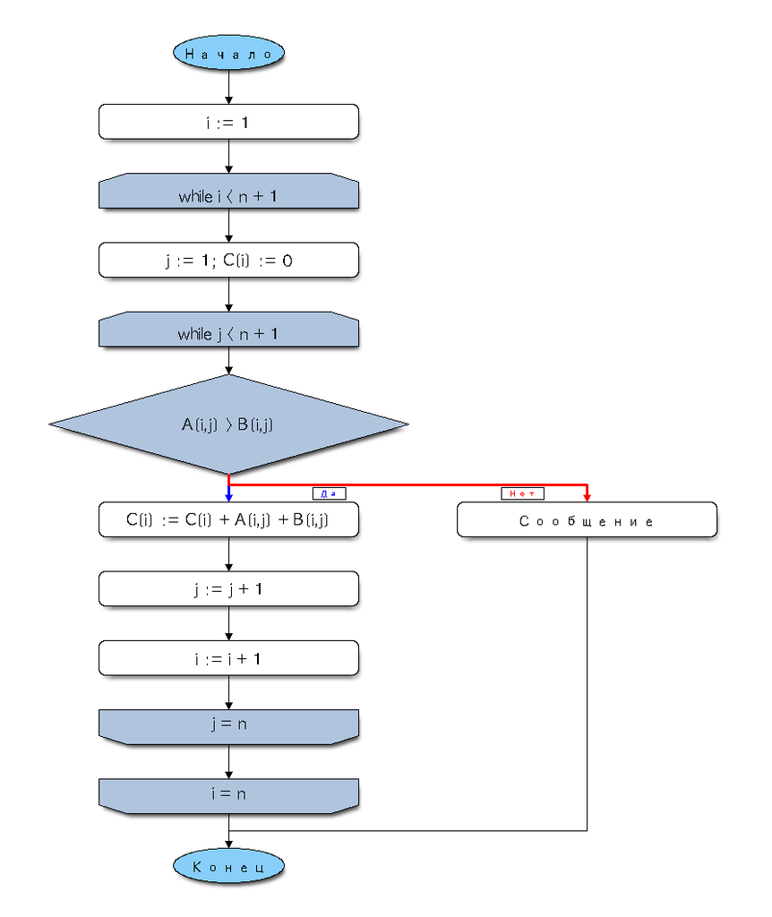

```python
Image("block_diagram2.png")
```

### 11. Программа на *Delphi*.

#### Программный код раскрытия абстракции.

```python
    procedure new_array(n: integer; A, B: M2; var C: A1; var i, j: integer);
    begin
        i := 1;
        while i < n + 1 do
        begin
            j := 1; C[i] := 0;
            while j < n + 1 do
            begin
                if A[i,j] > B[i,j] then
                    C[i] := C[i] + A[i,j] + B[i,j]
                else
                begin
                    writeln('Не все элементы матрицы A больше соответствующих элементов матрицы B');
                    exit;
                end;
                j := j + 1;
            end;
            i := i + 1;
        end;
    end;
```

**Диалоговый вариант {ввод названий файлов и данных из текстового файла, вывод на экран и в текстовый файл}**

Синтаксис:

[Pascal Tutorial](https://www.tutorialspoint.com/pascal/index.htm)

```python
program Lab12; // сохранить как lab12.dpr (DPR – Delphi PRoject)
{$APPTYPE CONSOLE}
Uses Windows; //
    type
        M1 = array [1..20,1..10] of integer;
        M2 = array [1..10,1..10] of integer;
        A1 = array [1..10] of integer;

    var
        fin, fout: string;
        tfin, tfout: TextFile;
        i, j, n, t: integer;
        X: M1;
        A, B: M2;
        C: A1;

    procedure read_in(var X: M1; var i, j, n: integer);
    begin
        i := 1;
        while not eof(tfin) do
        begin
            j := 1;
            while not eof(tfin) do
            begin
                read(tfin, X[i,j]);
                j := j + 1;
            end;
            i := i + 1;
            readln(tfin);
        end;
        n := round((i - 1) / 2);
    end;

    procedure write_in(n: integer; X: M1; var A, B: M2; var i, j: integer);
    begin
        writeln('Исходная матрица A');
        i := 1;
        while i < 2 * n + 1 do
        begin
            if i = n + 1 then
                writeln('Исходная матрица B');
            if i < n + 1 then
            begin
                j := 1;
                while j < n + 1 do
                begin
                    A[i,j] := X[i,j];
                    write(A[i,j]:5);
                    write(tfout, A[i,j]:5);
                    j := j + 1;
                end;
            end
            else
            begin
                j := 1;
                while j < n + 1 do
                begin
                    B[i-n,j] := X[i,j];
                    write(B[i-n,j]:5);
                    write(tfout, B[i-n,j]:5);
                    j := j + 1;
                end;
            end;
            writeln; writeln(tfout);
            i := i + 1;
        end;
    end;

    procedure new_array(n: integer; A, B: M2; var C: A1; var i, j: integer);
    begin
        i := 1;
        while i < n + 1 do
        begin
            j := 1; C[i] := 0;
            while j < n + 1 do
            begin
                if A[i,j] > B[i,j] then
                    C[i] := C[i] + A[i,j] + B[i,j]
                else
                begin
                    writeln('Не все элементы матрицы A больше соответствующих элементов матрицы B');
                    exit;
                end;
                j := j + 1;
            end;
            i := i + 1;
        end;
    end;

    procedure write_out(n: integer; C: A1; var i: integer);
    begin
        writeln('Сформированный массив C');
        i := 1;
        while i < n + 1 do
        begin
            write(C[i]:5);
            write(tfout, C[i]:5);
            i := i + 1;
        end;
        writeln; writeln(tfout);
    end;

    begin
        setConsoleCP(1251); //
        setConsoleOutputCP(1251); //

        {A0.1 - ввод-вывод входных данных}
        writeln('Лаб.12 Типовой Расчет' :40); {вывод заголовка c переходом на следующую строку по обр.4}

        {ввод-вывод строковой переменной - имени файла с входными данными по обр.1.1, 5.1}
        writeln('Текстовый файл с элементами исходных матриц: ');
        readln(fin); writeln(fin);

        {ввод-вывод строковой переменной - имени файла с выходными данными по обр.1.2, 5.2}
        writeln('Текстовый файл с элементами исходных матриц и результатами: ');
        readln(fout); writeln(fout);

        AssignFile(tfin, fin); reset(tfin); {открыть файл для чтения}
        AssignFile(tfout, fout); rewrite(tfout); {открыть файл для записи}

        read_in(X, i, j, n);
        CloseFile(tfin); {закрыть файл для чтения}

        if (i - 1 <> 2 * (j - 1)) then
        begin
            writeln('Некорректное число строк или столбцов');
            exit;
        end;

        write_in(n, X, A, B, i, j);

        {A0.2 - формирование нового массива}
        new_array(n, A, B, C, i, j);
        for i:=1 to 40 do
            write('='); {отделим визуально чертой и строкой введенные и выводимые значения}
        writeln;

        {A0.3 - вывод выходных данных}
        write_out(n, C, i);

        CloseFile(tfout); {закрыть файл для записи}

    end.
```

#### Вариант программы с именами файлов, заданными в качестве параметров.

```python
program Lab12; // сохранить как lab12.dpr (DPR – Delphi PRoject)
{$APPTYPE CONSOLE}
Uses Windows; //
    type
        M1 = array [1..20,1..10] of integer;
        M2 = array [1..10,1..10] of integer;
        A1 = array [1..10] of integer;

    var
        tfin, tfout: TextFile;
        i, j, n: integer;
        X: M1;
        A, B: M2;
        C: A1;

    procedure read_in(var X: M1; var i, j, n: integer);
    begin
        i := 1;
        while not eof(tfin) do
        begin
            j := 1;
            while not eof(tfin) do
            begin
                read(tfin, X[i,j]);
                j := j + 1;
            end;
            i := i + 1;
            readln(tfin);
        end;
        n := round((i - 1) / 2);

    end;

    procedure write_in(n: integer; X: M1; var A, B: M2; var i, j: integer);
    begin
        writeln('Исходная матрица A');
        i := 1;
        while i < 2 * n + 1 do
        begin
            if i = n + 1 then
                writeln('Исходная матрица B');
            if i < n + 1 then
            begin
                j := 1;
                while j < n + 1 do
                begin
                    A[i,j] := X[i,j];
                    write(A[i,j]:5);
                    write(tfout, A[i,j]:5);
                    j := j + 1;
                end;
            end
            else
            begin
                j := 1;
                while j < n + 1 do
                begin
                    B[i-n,j] := X[i,j];
                    write(B[i-n,j]:5);
                    write(tfout, B[i-n,j]:5);
                    j := j + 1;
                end;
            end;
            writeln; writeln(tfout);
            i := i + 1;
        end;
    end;

    procedure new_array(n: integer; A, B: M2; var C: A1; var i, j: integer);
    begin
        i := 1;
        while i < n + 1 do
        begin
            j := 1; C[i] := 0;
            while j < n + 1 do
            begin
                if A[i,j] > B[i,j] then
                    C[i] := C[i] + A[i,j] + B[i,j]
                else
                begin
                    writeln('Не все элементы матрицы A больше соответствующих элементов матрицы B');
                    exit;
                end;
                j := j + 1;
            end;
            i := i + 1;
        end;
    end;

    procedure write_out(n: integer; C: A1; var i: integer);
    begin
        writeln('Сформированный массив C');
        i := 1;
        while i < n + 1 do
        begin
            write(C[i]:5);
            write(tfout, C[i]:5);
            i := i + 1;
        end;
        writeln; writeln(tfout);
    end;

    begin
        setConsoleCP(1251); //
        setConsoleOutputCP(1251); //

        {A0.1 - ввод-вывод входных данных}
        writeln('Лаб.12 Типовой Расчет' :40); {вывод заголовка c переходом на следующую строку по обр.4}

        if (ParamCount<2) then
        begin
        writeln('CritError: Не заданы параметры программы');
        readln: exit;
        end;

        AssignFile(tfin, ParamStr(1)); reset(tfin); {открыть файл для чтения}
        AssignFile(tfout, ParamStr(2)); rewrite(tfout); {открыть файл для записи}

        read_in(X, i, j, n);
        CloseFile(tfin); {закрыть файл для чтения}

        if (i - 1 <> 2 * (j - 1)) then
        begin
            writeln('Некорректное число строк или столбцов');
            exit;
        end;

        write_in(n, X, A, B, i, j);

        {A0.2 - формирование нового массива}
        new_array(n, A, B, C, i, j);
        for i:=1 to 40 do
            write('='); {отделим визуально чертой и строкой введенные и выводимые значения}
        writeln;

        {A0.3 - вывод выходных данных}
        write_out(n, C, i);

        CloseFile(tfout); {закрыть файл для записи}

    end.
```

#### Вариант программы для онлайн-компилятора.

[Compile and Execute Pascal Online](http://www.compileonline.com/compile_pascal_online.php)

```python
// main.pas
program Lab12;

type
    M1 = array [1..20,1..10] of integer;
    M2 = array [1..10,1..10] of integer;
    A1 = array [1..10] of integer;

var
    i, j, n: integer;
    X: M1;
    A, B: M2;
    C: A1;

procedure read_in(var X: M1; var i, j, n: integer);

begin
    i := 1;
    while not eoln do
    begin
        j := 1;
        while not eoln do
        begin
            read(X[i,j]);
            j := j + 1;
        end;
        i := i + 1;
        readln;
    end;
    n := round((i - 1) / 2);
end;

procedure write_in(n: integer; X: M1; var A, B: M2; var i, j: integer);

begin
    writeln('Исходная матрица A');
    i := 1;
    while i < 2 * n + 1 do
    begin
        if i = n + 1 then
            writeln('Исходная матрица B');
        if i < n + 1 then
        begin
            j := 1;
            while j < n + 1 do
            begin
                A[i,j] := X[i,j];
                write(A[i,j]:5);
                j := j + 1;
            end;
        end
        else
        begin
            j := 1;
            while j < n + 1 do
            begin
                B[i-n,j] := X[i,j];
                write(B[i-n,j]:5);
                j := j + 1;
            end;
        end;
        writeln;
        i := i + 1;
    end;
end;

procedure new_array(n: integer; A, B: M2; var C: A1; var i, j: integer);

begin
    i := 1;
    while i < n + 1 do
    begin
        j := 1; C[i] := 0;
        while j < n + 1 do
        begin
            if A[i,j] > B[i,j] then
                C[i] := C[i] + A[i,j] + B[i,j]
            else
            begin
                writeln('Не все элементы матрицы A больше соответствующих элементов матрицы B');
                exit;
            end;
            j := j + 1;
        end;
        i := i + 1;
    end;
end;

procedure write_out(n: integer; C: A1; var i: integer);

begin
    writeln('Сформированный массив C');
    i := 1;
    while i < n + 1 do
    begin
        write(C[i]:5);
        i := i + 1;
    end;
end;

begin
    {A0.1 - ввод-вывод входных данных}
    writeln('Лаб.12 Типовой Расчет' :40); {вывод заголовка c переходом на следующую строку по обр.4}

    read_in(X, i, j, n);

    if (i - 1 <> 2 * (j - 1)) then
    begin
        writeln('Некорректное число строк или столбцов');
        exit;
    end;

    write_in(n, X, A, B, i, j);

    {A0.2 - формирование нового массива}
    new_array(n, A, B, C, i, j);

    for i:=1 to 40 do
        write('='); {отделим визуально чертой и строкой введенные и выводимые значения}
    writeln;

    {A0.3 - вывод выходных данных}
    write_out(n, C, i);
end.
```

```python
// STDIN
38 74 64 76 99
53 98 15 33 45
91 49 97 84 90
22 48 83  0 63
99 52 33 99 48
-76 -98 -99 -98 -82
-16 -22 -65 -83 -75
-25 -76 -66  -8  -2
-70 -45 -74 -70 -43
-37 -84 -64  -3 -94
```

### 12. Структурные тесты.

В разделе функциональные тесты не были учтены аномальные ситуации:

- входных данных нет совсем;
- на ввод не поданы две квадратные матрицы одинаковой размерности.

Фрагмент программы для учета имеющихся аномалий:

```python
    if (i - 1 <> 2 * (j - 1)) then
    begin
        writeln('Некорректное число строк или столбцов');
        exit;
    end;

    write_in(n, X, A, B, i, j);
```

Добавим 2 функцинальных теста.

| № теста | Входные данные | - | - | - | Ожидаемый результат | - | Смысл теста |
| --- | --- | --- | --- | --- | --- | --- | --- |
| - | - | - | - | - | - | - | - |
| 1 | fin = `AB_SC_6.txt` | fout = `ABC_SC_6.txt` | A = `[]` | B = `[]` | C = `-` | Сообщение = `Некорректное число строк или столбцов` | Аномальная ситуация - отсутствие входных данных |
| - | - | - | - | - | - | - | - |
| 2 | fin = `AB_SC_7.txt` | fout = `ABC_SC_7.txt` | A = `[2, 1, 1, 2, 1] [2, 2, 2, 1, 1] [1, 1, 1, 1, 1] [1, 1, 1, 1, 2] [1, 2, 1, 1, 2]` | B = `[]` | C = `-` | Сообщение = `Некорректное число строк или столбцов` | Аномальная ситуация - дана только одна квадратная матрица |

## Замечание.

Задача решена для ввода данных без разделения строк на две матрицы.

В случае наличия пустой строки между двумерными массивами в файле с входными данными решение упрощается.

Первые две процедуры можно объединить в одну и применить для каждой матрицы отдельно.

#### Вариант программы с именами файлов, заданными в качестве параметров.

```python
program Lab12; // сохранить как lab12.dpr (DPR – Delphi PRoject)
{$APPTYPE CONSOLE}
Uses Windows; //
    type
        M2 = array [1..10,1..10] of integer;
        A1 = array [1..10] of integer;

    var
        tfin, tfout: TextFile;
        i, j, n: integer;
        A, B: M2;
        C: A1;

    procedure read_in(var A: M2; var i, j, n: integer);
    begin
        i := 1;
        while not eof(tfin) do
        begin
            j := 1;
            while not eof(tfin) do
            begin
                read(tfin, A[i,j]);
                write(A[i,j]:5);
                write(tfout, A[i,j]:5);
                j := j + 1;
            end;
            i := i + 1;
            readln(tfin); writeln; writeln(tfout);
        end;
        n := i - 1;
    end;

    procedure new_array(n: integer; A, B: M2; var C: A1; var i, j: integer);
    begin
        i := 1;
        while i < n + 1 do
        begin
            j := 1; C[i] := 0;
            while j < n + 1 do
            begin
                if A[i,j] > B[i,j] then
                    C[i] := C[i] + A[i,j] + B[i,j]
                else
                begin
                    writeln('Не все элементы матрицы A больше соответствующих элементов матрицы B');
                    exit;
                end;
                j := j + 1;
            end;
            i := i + 1;
        end;
    end;

    procedure write_out(n: integer; C: A1; var i: integer);
    begin
        writeln('Сформированный массив C');
        i := 1;
        while i < n + 1 do
        begin
            write(C[i]:5);
            write(tfout, C[i]:5);
            i := i + 1;
        end;
        writeln; writeln(tfout);
    end;

    begin
        setConsoleCP(1251); //
        setConsoleOutputCP(1251); //

        {A0.1 - ввод-вывод входных данных}
        writeln('Лаб.12 Типовой Расчет' :40); {вывод заголовка c переходом на следующую строку по обр.4}

        if (ParamCount<2) then
        begin
        writeln('CritError: Не заданы параметры программы');
        readln: exit;
        end;

        AssignFile(tfin, ParamStr(1)); reset(tfin); {открыть файл для чтения}
        AssignFile(tfout, ParamStr(2)); rewrite(tfout); {открыть файл для записи}

        writeln('Исходная матрица A: ');
        read_in(A, i, j, n);
        readln; writeln; writeln(tfout);
        writeln('Исходная матрица B: ');
        read_in(B, i, j, n);

        CloseFile(tfin); {закрыть файл для чтения}

        if (i - 1 <> j - 1) then
        begin
            writeln('Некорректное число строк или столбцов');
            exit;
        end;

        {A0.2 - формирование нового массива}
        new_array(n, A, B, C, i, j);

        for i:=1 to 40 do
            write('='); {отделим визуально чертой и строкой введенные и выводимые значения}
        writeln; writeln(tfout);

        {A0.3 - вывод выходных данных}
        write_out(n, C, i);

        CloseFile(tfout); {закрыть файл для записи}

    end.
```

#### Вариант программы для онлайн-компилятора.

[Compile and Execute Pascal Online](http://www.compileonline.com/compile_pascal_online.php)

```python
// main.pas
program Lab12;

type
    M2 = array [1..10,1..10] of integer;
    A1 = array [1..10] of integer;

var
    i, j, n: integer;
    A, B: M2;
    C: A1;

procedure read_in(var A: M2; var i, j, n: integer);
begin
    i := 1;
    while not eoln do
    begin
        j := 1;
        while not eoln do
        begin
            read(A[i,j]);
            write(A[i,j]:5);
            j := j + 1;
        end;
        i := i + 1;
        readln; writeln;
    end;
    n := i - 1;
end;

procedure new_array(n: integer; A, B: M2; var C: A1; var i, j: integer);
begin
    i := 1;
    while i < n + 1 do
    begin
        j := 1; C[i] := 0;
        while j < n + 1 do
        begin
            if A[i,j] > B[i,j] then
                C[i] := C[i] + A[i,j] + B[i,j]
            else
            begin
                writeln('Не все элементы матрицы A больше соответствующих элементов матрицы B');
                exit;
            end;
            j := j + 1;
        end;
        i := i + 1;
    end;
end;

procedure write_out(n: integer; C: A1; var i: integer);
begin
    writeln('Сформированный массив C');
    i := 1;
    while i < n + 1 do
    begin
        write(C[i]:5);
        i := i + 1;
    end;
end;

begin
    {A0.1 - ввод-вывод входных данных}
    writeln('Лаб.12 Типовой Расчет' :40); {вывод заголовка c переходом на следующую строку по обр.4}

    writeln('Исходная матрица A: ');
    read_in(A, i, j, n);
    readln; writeln;
    writeln('Исходная матрица B: ');
    read_in(B, i, j, n);

    if (i - 1 <> j - 1) then
    begin
        writeln('Некорректное число строк или столбцов');
        exit;
    end;

    {A0.2 - формирование нового массива}
    new_array(n, A, B, C, i, j);

    for i:=1 to 40 do
        write('='); {отделим визуально чертой и строкой введенные и выводимые значения}
    writeln;

    {A0.3 - вывод выходных данных}
    write_out(n, C, i);
end.
```

```python
// STDIN
38 74 64 76 99
53 98 15 33 45
91 49 97 84 90
22 48 83  0 63
99 52 33 99 48

-76 -98 -99 -98 -82
-16 -22 -65 -83 -75
-25 -76 -66  -8  -2
-70 -45 -74 -70 -43
-37 -84 -64  -3 -94
```